# Car prices model

2022-11-30

This R markdown file shows the data cleaning process as well as the process used to generate first order, interaction model and higher order models. It also shows the assumptions checks performed. However, the main elaboration on what each step means is in the report in PDF format.

# Cleaning

```r
car_dataset <- read.csv('Car details.csv')

#Remove rows with NA (221 rows)
car_dataset <- car_dataset[complete.cases(car_dataset), ]
```

```r
#Remove the 'kmpl' / 'km per kg' for the mileage column
car_dataset$mileage = as.numeric(gsub("[^0-9.<>]", "", car_dataset$mileage))
#Remove Zero value mileage rows (17 rows)
car_dataset = car_dataset[car_dataset$mileage!=0, ]
```

```r
#Remove the 'CC' for the engine column
car_dataset$engine = as.numeric(gsub("[^0-9.<>]", "", car_dataset$engine))
```

```r
#Remove the 'bhp' for the max_power column
car_dataset$max_power = as.numeric(gsub("[^0-9.<>]", "", car_dataset$max_power))
```

```r
#break the torque column into torque_nm and torque_rpm columns
for (i in 1:nrow(car_dataset)){
  if(grepl('(kgm@ rpm)',car_dataset$torque[i])){
    car_dataset$torque_nm[i] <-as.numeric(strsplit(car_dataset$torque[i], "[@]")[[1]][1])*9.80665 #covert from kgm to nm
    car_dataset$torque_rpm[i] <-as.numeric(gsub("[^0-9.<>]", "",strsplit(car_dataset$torque[i], "@|-|~")[[1]][2]))
  }
  else if (grepl('kgm at',tolower(car_dataset$torque[i])))
  {
    car_dataset$torque_nm[i] <- as.numeric(gsub("[^0-9.<>]", "",strsplit(car_dataset$torque[i], "[at]")[[1]][1]))*9.80665
    car_dataset$torque_rpm[i] <- as.numeric(gsub("[^0-9.<>]", "",strsplit(car_dataset$torque[i], c("at|-|~"))[[1]][2]))
  }
  else if (grepl('nm at',tolower(car_dataset$torque[i])))
  {
    car_dataset$torque_nm[i] <- as.numeric(gsub("[^0-9.<>]", "",strsplit(car_dataset$torque[i], "[at]")[[1]][1]))
    car_dataset$torque_rpm[i] <- as.numeric(gsub("[^0-9.<>]", "",strsplit(car_dataset$torque[i], c("at|-|~"))[[1]][2]))
  }
  else if (grepl(' / ',car_dataset$torque[i]))
  {
    car_dataset$torque_nm[i] <- as.numeric(gsub("[^0-9.<>]", "",strsplit(car_dataset$torque[i], " / ")[[1]][1]))
    car_dataset$torque_rpm[i] <- as.numeric(gsub("[^0-9.<>]", "",strsplit(car_dataset$torque[i], c(" / "))[[1]][2]))
  }
  else if (grepl('kgm@',car_dataset$torque[i]))
  {
    car_dataset$torque_nm[i] <- as.numeric(gsub("[^0-9.<>]", "",strsplit(car_dataset$torque[i], "[@]|\\(")[[1]][1]))*9.80665
    car_dataset$torque_rpm[i] <- as.numeric(gsub("[^0-9.<>]", "",strsplit(car_dataset$torque[i], c("@|-|~"))[[1]][2]))
  }
  else
  {
    car_dataset$torque_nm[i] <- as.numeric(gsub("[^0-9.<>]", "",strsplit(car_dataset$torque[i], "[@]|\\(")[[1]][1]))
    car_dataset$torque_rpm[i] <- as.numeric(gsub("[^0-9.<>]", "",strsplit(car_dataset$torque[i], c("@|-|~"))[[1]][2]))
  }
}
```

```r
#Remove rows with NA in torque_rpm (35 rows)
car_dataset <- car_dataset[complete.cases(car_dataset$torque_rpm), ]
```

# Testing for colinearity

```r
library(mctest)
firstordermodel<-lm(selling_price~year+km_driven+factor(fuel)+factor(seller_type)+factor(transmission)+factor(owner)+mileage+engine+max_power+seats+torque_rpm, data=car_dataset)
imcdiag(firstordermodel, method="VIF")
```

```
##
## Call:
## imcdiag(mod = firstordermodel, method = "VIF")
##
##
##  VIF Multicollinearity Diagnostics
##
##                                         VIF detection
## year                                 2.0953         0
## km_driven                            1.4386         0
## factor(fuel)Diesel                  40.2806         1
## factor(fuel)LPG                      1.6951         0
## factor(fuel)Petrol                  39.1833         1
## factor(seller_type)Individual        1.4686         0
## factor(seller_type)Trustmark Dealer  1.2542         0
## factor(transmission)Manual           1.6409         0
## factor(owner)Fourth & Above Owner    1.1005         0
## factor(owner)Second Owner            1.2754         0
## factor(owner)Test Drive Car          1.0109         0
## factor(owner)Third Owner             1.1996         0
## mileage                              3.0548         0
## engine                               5.5554         0
## max_power                            3.2619         0
## seats                                2.3255         0
## torque_rpm                           4.2029         0
##
## Multicollinearity may be due to factor(fuel)Diesel factor(fuel)Petrol regressors
##
## 1 --> COLLINEARITY is detected by the test
## 0 --> COLLINEARITY is not detected by the test
##
## ===================================
```

# Individual t-tests

```r
summary(firstordermodel)
```

```
##
## Call:
## lm(formula = selling_price ~ year + km_driven + factor(fuel) +
##     factor(seller_type) + factor(transmission) + factor(owner) +
##     mileage + engine + max_power + seats + torque_rpm, data = car_dataset)
##
## Residuals:
##      Min       1Q   Median       3Q      Max
## -2194974  -189249    13230   162870  4367716
##
## Coefficients:
##                                       Estimate Std. Error t value Pr(>|t|)
## (Intercept)                         -6.430e+07  3.756e+06 -17.118  < 2e-16 ***
## year                                 3.209e+04  1.879e+03  17.077  < 2e-16 ***
## km_driven                           -9.418e-01  1.057e-01  -8.913  < 2e-16 ***
## factor(fuel)Diesel                  -2.152e+05  6.381e+04  -3.373 0.000748 ***
## factor(fuel)LPG                      2.399e+05  9.791e+04   2.450 0.014316 *
## factor(fuel)Petrol                  -1.571e+03  6.307e+04  -0.025 0.980130
## factor(seller_type)Individual       -2.732e+05  1.615e+04 -16.912  < 2e-16 ***
## factor(seller_type)Trustmark Dealer -3.343e+05  3.286e+04 -10.173  < 2e-16 ***
## factor(transmission)Manual          -4.278e+05  1.924e+04 -22.233  < 2e-16 ***
## factor(owner)Fourth & Above Owner    5.248e+03  3.731e+04   0.141 0.888142
## factor(owner)Second Owner           -4.322e+04  1.296e+04  -3.335 0.000858 ***
## factor(owner)Test Drive Car          1.984e+06  1.997e+05   9.934  < 2e-16 ***
## factor(owner)Third Owner            -1.363e+04  2.231e+04  -0.611 0.541258
## mileage                              1.692e+04  2.219e+03   7.624 2.75e-14 ***
## engine                               1.294e+02  2.346e+01   5.515 3.59e-08 ***
## max_power                            1.225e+04  2.570e+02  47.646  < 2e-16 ***
## seats                               -3.813e+04  7.955e+03  -4.793 1.67e-06 ***
## torque_rpm                          -1.207e+02  9.021e+00 -13.380  < 2e-16 ***
## ---
## Signif. codes:  0 '***' 0.001 '**' 0.01 '*' 0.05 '.' 0.1 ' ' 1
##
## Residual standard error: 443900 on 7837 degrees of freedom
## Multiple R-squared:  0.6821, Adjusted R-squared:  0.6814
## F-statistic: 989.2 on 17 and 7837 DF,  p-value: < 2.2e-16
```

# Best Subset

```r
aprs =ols_step_best_subset(firstordermodel, details=TRUE)
cp<-c(aprs$cp)
AIC<-c(aprs$aic)
AdjustedR<-c(aprs$adjr)

cbind(AdjustedR,cp,AIC)
```

```
##       AdjustedR         cp      AIC
##  [1,] 0.5463546 3331.20899 229355.4
##  [2,] 0.6102392 1757.25232 228164.2
##  [3,] 0.6430044  950.58254 227475.4
##  [4,] 0.6607986  511.94464 227075.8
##  [5,] 0.6657138  388.65051 226965.1
##  [6,] 0.6695501  295.14547 226875.5
##  [7,] 0.6743263  178.52764 226762.1
##  [8,] 0.6768440  115.50213 226704.1
##  [9,] 0.6799655   39.68024 226628.9
## [10,] 0.6805224   26.97430 226616.2
## [11,] 0.6814156    6.00000 226595.2
```

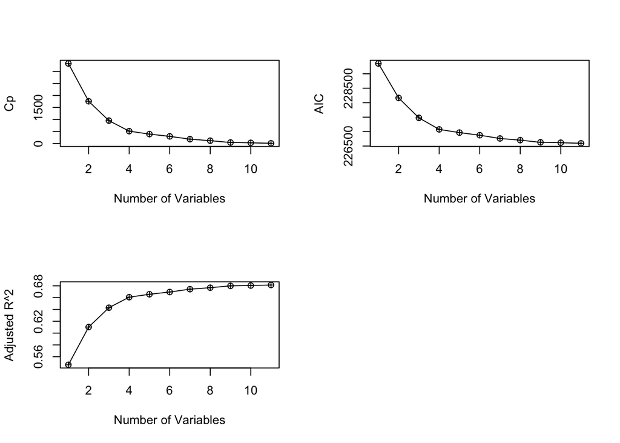

```r
par(mfrow=c(2,2)) # split the plotting panel into a 2 x 2 grid
plot(aprs$cp,type = "o",pch=10, xlab="Number of Variables",ylab= "Cp")
plot(aprs$aic,type = "o",pch=10, xlab="Number of Variables",ylab= "AIC")
plot(aprs$adjr,type = "o",pch=10, xlab="Number of Variables",ylab= "Adjusted R^2")
```

```r
best.subset<-regsubsets(selling_price~year+km_driven+factor(fuel)+factor(seller_type)+factor(transmission)+factor(owner)+mileage+engine+max_power+seats+torque_rpm, data=car_dataset, nv=11 )
reg.summary = summary(best.subset)
summary(best.subset)
```

```
## Subset selection object
## Call: regsubsets.formula(selling_price ~ year + km_driven + factor(fuel) +
##     factor(seller_type) + factor(transmission) + factor(owner) +
##     mileage + engine + max_power + seats + torque_rpm, data = car_dataset,
##     nv = 11)
## 17 Variables  (and intercept)
##                                     Forced in Forced out
## year                                    FALSE      FALSE
## km_driven                               FALSE      FALSE
## factor(fuel)Diesel                      FALSE      FALSE
## factor(fuel)LPG                         FALSE      FALSE
## factor(fuel)Petrol                      FALSE      FALSE
## factor(seller_type)Individual           FALSE      FALSE
## factor(seller_type)Trustmark Dealer     FALSE      FALSE
## factor(transmission)Manual              FALSE      FALSE
## factor(owner)Fourth & Above Owner       FALSE      FALSE
## factor(owner)Second Owner               FALSE      FALSE
## factor(owner)Test Drive Car             FALSE      FALSE
## factor(owner)Third Owner                FALSE      FALSE
## mileage                                 FALSE      FALSE
## engine                                  FALSE      FALSE
## max_power                               FALSE      FALSE
## seats                                   FALSE      FALSE
## torque_rpm                              FALSE      FALSE
## 1 subsets of each size up to 11
## Selection Algorithm: exhaustive
##           year km_driven factor(fuel)Diesel factor(fuel)LPG factor(fuel)Petrol
## 1  ( 1 )  " "  " "       " "                " "             " "
## 2  ( 1 )  "*"  " "       " "                " "             " "
## 3  ( 1 )  "*"  " "       " "                " "             " "
## 4  ( 1 )  "*"  " "       " "                " "             " "
## 5  ( 1 )  "*"  " "       " "                " "             " "
## 6  ( 1 )  "*"  " "       " "                " "             " "
## 7  ( 1 )  "*"  "*"       " "                " "             " "
## 8  ( 1 )  "*"  "*"       " "                " "             " "
## 9  ( 1 )  "*"  "*"       " "                " "             " "
## 10  ( 1 ) "*"  "*"       "*"                " "             " "
## 11  ( 1 ) "*"  "*"       "*"                " "             " "
##           factor(seller_type)Individual factor(seller_type)Trustmark Dealer
## 1  ( 1 )  " "                           " "
```

[output cut: 31 more lines]

```
## 9  ( 1 )  " "                       "*"
## 10  ( 1 ) " "                       "*"
## 11  ( 1 ) " "                       "*"
##           factor(owner)Third Owner mileage engine max_power seats torque_rpm
## 1  ( 1 )  " "                      " "     " "    "*"       " "   " "
## 2  ( 1 )  " "                      " "     " "    "*"       " "   " "
## 3  ( 1 )  " "                      " "     " "    "*"       " "   " "
## 4  ( 1 )  " "                      " "     " "    "*"       " "   " "
## 5  ( 1 )  " "                      " "     " "    "*"       " "   " "
## 6  ( 1 )  " "                      " "     " "    "*"       " "   " "
## 7  ( 1 )  " "                      " "     " "    "*"       " "   "*"
## 8  ( 1 )  " "                      " "     " "    "*"       " "   "*"
## 9  ( 1 )  " "                      " "     " "    "*"       "*"   "*"
## 10  ( 1 ) " "                      "*"     " "    "*"       " "   "*"
## 11  ( 1 ) " "                      "*"     "*"    "*"       " "   "*"
```

```r
rsquare<-c(reg.summary$rsq)
cp<-c(reg.summary$cp)
AdjustedR<-c(reg.summary$adjr2)
RMSE<-c(reg.summary$rss)
BIC<-c(reg.summary$bic)
cbind(rsquare,cp,BIC,RMSE,AdjustedR)
```

```
##         rsquare         cp       BIC         RMSE AdjustedR
##  [1,] 0.5464124 3331.20899 -6191.965 2.203705e+15 0.5463546
##  [2,] 0.6103384 1757.25232 -7376.248 1.893128e+15 0.6102392
##  [3,] 0.6431408  950.58254 -8058.025 1.733761e+15 0.6430044
##  [4,] 0.6544121  674.71311 -8301.157 1.679001e+15 0.6542360
##  [5,] 0.6610145  513.94464 -8443.710 1.646924e+15 0.6607986
##  [6,] 0.6655708  403.61864 -8541.036 1.624787e+15 0.6653151
##  [7,] 0.6698752  299.50357 -8633.824 1.603875e+15 0.6695807
##  [8,] 0.6742847  192.79794 -8730.481 1.582452e+15 0.6739526
##  [9,] 0.6767009  135.23129 -8779.999 1.570713e+15 0.6763300
## [10,] 0.6797097   63.05667 -8844.475 1.556095e+15 0.6793013
## [11,] 0.6803057   50.36254 -8850.137 1.553200e+15 0.6798573
```

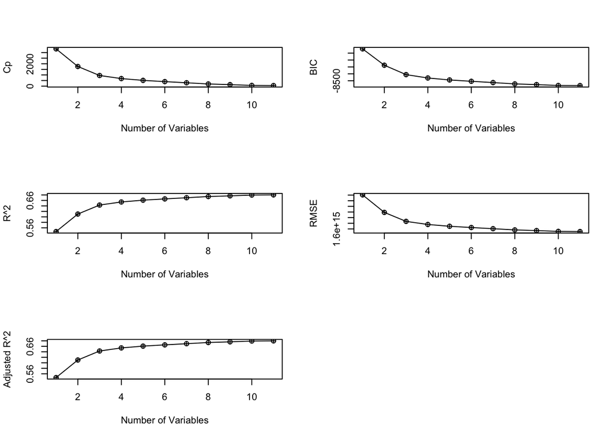

```r
par(mfrow=c(3,2)) # split the plotting panel into a 3 x 2 grid
plot(reg.summary$cp,type = "o",pch=10, xlab="Number of Variables",ylab= "Cp")
plot(reg.summary$bic,type = "o",pch=10, xlab="Number of Variables",ylab= "BIC")
plot(reg.summary$rsq,type = "o",pch=10, xlab="Number of Variables",ylab= "R^2")
plot(reg.summary$rss,type = "o",pch=10, xlab="Number of Variables",ylab= "RMSE")
plot(reg.summary$adjr2,type = "o",pch=10, xlab="Number of Variables",ylab= "Adjusted R^2")
```

# F test on seats

```r
reduced_model = lm(selling_price~year+km_driven+factor(fuel)+factor(seller_type)+factor(transmission)+factor(owner)+mileage+engine+max_power+torque_rpm, data=car_dataset)
anova(reduced_model, firstordermodel)
```

|  | Res.Df | RSS | Df | Sum of Sq | F | Pr(>F) |
| --- | --- | --- | --- | --- | --- | --- |
| 1 | 7838 | 1.548984e+15 | NA | NA | NA | NA |
| 2 | 7837 | 1.544457e+15 | 1 | 4.527601e+12 | 22.9743 | 1.672048e-06 |

# Interaction models

```r
intmodel = lm(selling_price~(year+km_driven+factor(fuel)+factor(seller_type)+factor(transmission)+factor(owner)+mileage+engine+max_power+seats+torque_rpm)^2, data=car_dataset)

# Took out insignifant terms
reducedint = lm(selling_price~year+km_driven+factor(fuel)+factor(seller_type)+factor(transmission)+factor(owner)+mileage+engine+max_power+seats+torque_rpm + year*km_driven + year*factor(seller_type) + year*factor(transmission) + year*mileage + year*engine + year*max_power + year*torque_rpm + km_driven*factor(seller_type) + km_driven*factor(transmission) + km_driven*max_power + factor(fuel)*factor(transmission) + factor(fuel)*factor(owner) + factor(seller_type)*factor(transmission) + factor(seller_type)*factor(owner) + factor(seller_type)*mileage + factor(seller_type)*engine +factor(seller_type)*max_power + factor(transmission)*factor(owner) + factor(transmission)*mileage + factor(transmission)*engine + factor(transmission)*max_power + factor(transmission)*seats + factor(transmission)*torque_rpm + factor(owner)*mileage + factor(owner)*engine + factor(owner)*torque_rpm + mileage*engine + mileage*max_power + engine*max_power + engine*torque_rpm + max_power*seats + max_power*torque_rpm, data=car_dataset)

# took out interaction between factor owner and torque rpm
reducedint2 = lm(selling_price~year+km_driven+factor(fuel)+factor(seller_type)+factor(transmission)+factor(owner)+mileage+engine+max_power+seats+torque_rpm + year*km_driven + year*factor(seller_type) + year*factor(transmission) + year*mileage + year*engine + year*max_power + year*torque_rpm + km_driven*factor(seller_type) + km_driven*factor(transmission) + km_driven*max_power + factor(fuel)*factor(transmission) + factor(fuel)*factor(owner) + factor(seller_type)*factor(transmission) + factor(seller_type)*factor(owner) + factor(seller_type)*mileage + factor(seller_type)*engine +factor(seller_type)*max_power + factor(transmission)*factor(owner) + factor(transmission)*mileage + factor(transmission)*engine + factor(transmission)*max_power + factor(transmission)*seats + factor(transmission)*torque_rpm + factor(owner)*mileage + factor(owner)*engine + mileage*engine + mileage*max_power + engine*max_power + engine*torque_rpm + max_power*seats + max_power*torque_rpm, data=car_dataset)
summary(reducedint2)
```

```
##
## Call:
## lm(formula = selling_price ~ year + km_driven + factor(fuel) +
##     factor(seller_type) + factor(transmission) + factor(owner) +
##     mileage + engine + max_power + seats + torque_rpm + year *
##     km_driven + year * factor(seller_type) + year * factor(transmission) +
##     year * mileage + year * engine + year * max_power + year *
##     torque_rpm + km_driven * factor(seller_type) + km_driven *
##     factor(transmission) + km_driven * max_power + factor(fuel) *
##     factor(transmission) + factor(fuel) * factor(owner) + factor(seller_type) *
##     factor(transmission) + factor(seller_type) * factor(owner) +
##     factor(seller_type) * mileage + factor(seller_type) * engine +
##     factor(seller_type) * max_power + factor(transmission) *
##     factor(owner) + factor(transmission) * mileage + factor(transmission) *
##     engine + factor(transmission) * max_power + factor(transmission) *
##     seats + factor(transmission) * torque_rpm + factor(owner) *
##     mileage + factor(owner) * engine + mileage * engine + mileage *
##     max_power + engine * max_power + engine * torque_rpm + max_power *
##     seats + max_power * torque_rpm, data = car_dataset)
##
## Residuals:
##      Min       1Q   Median       3Q      Max
## -2823325   -82100    -3035    81121  2124031
##
## Coefficients: (11 not defined because of singularities)
##                                                                         Estimate
## (Intercept)                                                           -4.410e+07
## year                                                                   2.043e+04
## km_driven                                                              2.099e+02
## factor(fuel)Diesel                                                     4.621e+05
## factor(fuel)LPG                                                       -3.421e+04
## factor(fuel)Petrol                                                    -6.874e+04
## factor(seller_type)Individual                                          5.169e+07
## factor(seller_type)Trustmark Dealer                                    4.170e+07
## factor(transmission)Manual                                             9.040e+07
## factor(owner)Fourth & Above Owner                                      6.515e+05
## factor(owner)Second Owner                                              4.965e+04
## factor(owner)Test Drive Car                                            3.817e+07
## factor(owner)Third Owner                                               6.300e+05
## mileage                                                               -3.408e+06
```

[output cut: 401 more lines]

```
## factor(owner)Second Owner:engine
## factor(owner)Test Drive Car:engine
## factor(owner)Third Owner:engine
## mileage:engine                                                        ***
## mileage:max_power                                                     ***
## engine:max_power                                                      ***
## engine:torque_rpm                                                     ***
## max_power:seats                                                       ***
## max_power:torque_rpm                                                  ***
## ---
## Signif. codes:  0 '***' 0.001 '**' 0.01 '*' 0.05 '.' 0.1 ' ' 1
##
## Residual standard error: 237900 on 7782 degrees of freedom
## Multiple R-squared:  0.9093, Adjusted R-squared:  0.9085
## F-statistic:  1084 on 72 and 7782 DF,  p-value: < 2.2e-16
```

```r
reducedint3 = lm(log(selling_price)~year+km_driven+factor(fuel)+factor(seller_type)+factor(transmission)+factor(owner)+mileage+engine+max_power+seats+torque_rpm + year*km_driven + year*factor(seller_type) + year*factor(transmission) + year*mileage + year*engine + year*max_power + year*torque_rpm + km_driven*factor(seller_type) + km_driven*factor(transmission) + km_driven*max_power + factor(fuel)*factor(transmission) + factor(fuel)*factor(owner) + factor(seller_type)*factor(transmission) + factor(seller_type)*factor(owner) + factor(seller_type)*mileage + factor(seller_type)*engine +factor(seller_type)*max_power + factor(transmission)*factor(owner) + factor(transmission)*mileage + factor(transmission)*engine + factor(transmission)*max_power + factor(transmission)*seats + factor(transmission)*torque_rpm + factor(owner)*mileage + factor(owner)*engine + mileage*engine + mileage*max_power + engine*max_power + engine*torque_rpm + max_power*seats + max_power*torque_rpm, data=car_dataset)
```

# Partial F-test on interaction model

```r
anova(reducedint2, reducedint)
```

|  | Res.Df | RSS | Df | Sum of Sq | F | Pr(>F) |
| --- | --- | --- | --- | --- | --- | --- |
| 1 | 7782 | 4.405873e+14 | NA | NA | NA | NA |
| 2 | 7779 | 4.401984e+14 | 3 | 388861219458 | 2.290597 | 0.0761858 |

```r
summary(reducedint2)
```

```
##
## Call:
## lm(formula = selling_price ~ year + km_driven + factor(fuel) +
##     factor(seller_type) + factor(transmission) + factor(owner) +
##     mileage + engine + max_power + seats + torque_rpm + year *
##     km_driven + year * factor(seller_type) + year * factor(transmission) +
##     year * mileage + year * engine + year * max_power + year *
##     torque_rpm + km_driven * factor(seller_type) + km_driven *
##     factor(transmission) + km_driven * max_power + factor(fuel) *
##     factor(transmission) + factor(fuel) * factor(owner) + factor(seller_type) *
##     factor(transmission) + factor(seller_type) * factor(owner) +
##     factor(seller_type) * mileage + factor(seller_type) * engine +
##     factor(seller_type) * max_power + factor(transmission) *
##     factor(owner) + factor(transmission) * mileage + factor(transmission) *
##     engine + factor(transmission) * max_power + factor(transmission) *
##     seats + factor(transmission) * torque_rpm + factor(owner) *
##     mileage + factor(owner) * engine + mileage * engine + mileage *
##     max_power + engine * max_power + engine * torque_rpm + max_power *
##     seats + max_power * torque_rpm, data = car_dataset)
##
## Residuals:
##      Min       1Q   Median       3Q      Max
## -2823325   -82100    -3035    81121  2124031
##
## Coefficients: (11 not defined because of singularities)
##                                                                         Estimate
## (Intercept)                                                           -4.410e+07
## year                                                                   2.043e+04
## km_driven                                                              2.099e+02
## factor(fuel)Diesel                                                     4.621e+05
## factor(fuel)LPG                                                       -3.421e+04
## factor(fuel)Petrol                                                    -6.874e+04
## factor(seller_type)Individual                                          5.169e+07
## factor(seller_type)Trustmark Dealer                                    4.170e+07
## factor(transmission)Manual                                             9.040e+07
## factor(owner)Fourth & Above Owner                                      6.515e+05
## factor(owner)Second Owner                                              4.965e+04
## factor(owner)Test Drive Car                                            3.817e+07
## factor(owner)Third Owner                                               6.300e+05
## mileage                                                               -3.408e+06
```

[output cut: 401 more lines]

```
## factor(owner)Second Owner:engine
## factor(owner)Test Drive Car:engine
## factor(owner)Third Owner:engine
## mileage:engine                                                        ***
## mileage:max_power                                                     ***
## engine:max_power                                                      ***
## engine:torque_rpm                                                     ***
## max_power:seats                                                       ***
## max_power:torque_rpm                                                  ***
## ---
## Signif. codes:  0 '***' 0.001 '**' 0.01 '*' 0.05 '.' 0.1 ' ' 1
##
## Residual standard error: 237900 on 7782 degrees of freedom
## Multiple R-squared:  0.9093, Adjusted R-squared:  0.9085
## F-statistic:  1084 on 72 and 7782 DF,  p-value: < 2.2e-16
```

# Higher order

```r
reducedint2_quad = lm(selling_price~year+km_driven+factor(fuel)+factor(seller_type)+factor(transmission)+factor(owner)+mileage+engine+I(engine^2)+max_power+I(max_power^2)+seats+torque_rpm + year*km_driven + year*factor(seller_type) + year*factor(transmission) + year*mileage + year*engine + year*max_power + year*torque_rpm + km_driven*factor(seller_type) + km_driven*factor(transmission) + km_driven*max_power + factor(fuel)*factor(transmission) + factor(fuel)*factor(owner) + factor(seller_type)*factor(transmission) + factor(seller_type)*factor(owner) + factor(seller_type)*mileage + factor(seller_type)*engine +factor(seller_type)*max_power + factor(transmission)*factor(owner) + factor(transmission)*mileage + factor(transmission)*engine + factor(transmission)*max_power + factor(transmission)*seats + factor(transmission)*torque_rpm + factor(owner)*mileage + factor(owner)*engine + mileage*engine + mileage*max_power + engine*max_power + engine*torque_rpm + max_power*seats + max_power*torque_rpm, data=car_dataset)

summary(reducedint2_quad)
```

```
##
## Call:
## lm(formula = selling_price ~ year + km_driven + factor(fuel) +
##     factor(seller_type) + factor(transmission) + factor(owner) +
##     mileage + engine + I(engine^2) + max_power + I(max_power^2) +
##     seats + torque_rpm + year * km_driven + year * factor(seller_type) +
##     year * factor(transmission) + year * mileage + year * engine +
##     year * max_power + year * torque_rpm + km_driven * factor(seller_type) +
##     km_driven * factor(transmission) + km_driven * max_power +
##     factor(fuel) * factor(transmission) + factor(fuel) * factor(owner) +
##     factor(seller_type) * factor(transmission) + factor(seller_type) *
##     factor(owner) + factor(seller_type) * mileage + factor(seller_type) *
##     engine + factor(seller_type) * max_power + factor(transmission) *
##     factor(owner) + factor(transmission) * mileage + factor(transmission) *
##     engine + factor(transmission) * max_power + factor(transmission) *
##     seats + factor(transmission) * torque_rpm + factor(owner) *
##     mileage + factor(owner) * engine + mileage * engine + mileage *
##     max_power + engine * max_power + engine * torque_rpm + max_power *
##     seats + max_power * torque_rpm, data = car_dataset)
##
## Residuals:
##      Min       1Q   Median       3Q      Max
## -2785325   -82344    -2261    79920  2142333
##
## Coefficients: (11 not defined because of singularities)
##                                                                         Estimate
## (Intercept)                                                           -5.463e+07
## year                                                                   2.539e+04
## km_driven                                                              2.212e+02
## factor(fuel)Diesel                                                     4.473e+05
## factor(fuel)LPG                                                       -3.152e+04
## factor(fuel)Petrol                                                    -5.578e+04
## factor(seller_type)Individual                                          5.326e+07
## factor(seller_type)Trustmark Dealer                                    3.558e+07
## factor(transmission)Manual                                             8.760e+07
## factor(owner)Fourth & Above Owner                                      6.678e+05
## factor(owner)Second Owner                                              5.399e+04
## factor(owner)Test Drive Car                                            3.856e+07
## factor(owner)Third Owner                                               6.089e+05
## mileage                                                               -2.955e+06
```

[output cut: 411 more lines]

```
## factor(owner)Second Owner:engine
## factor(owner)Test Drive Car:engine
## factor(owner)Third Owner:engine
## mileage:engine                                                        ***
## mileage:max_power                                                     ***
## engine:max_power                                                      ***
## engine:torque_rpm                                                     ***
## max_power:seats                                                       ***
## max_power:torque_rpm                                                  ***
## ---
## Signif. codes:  0 '***' 0.001 '**' 0.01 '*' 0.05 '.' 0.1 ' ' 1
##
## Residual standard error: 237300 on 7780 degrees of freedom
## Multiple R-squared:  0.9099, Adjusted R-squared:  0.909
## F-statistic:  1061 on 74 and 7780 DF,  p-value: < 2.2e-16
```

# Assumptions

## Linearality

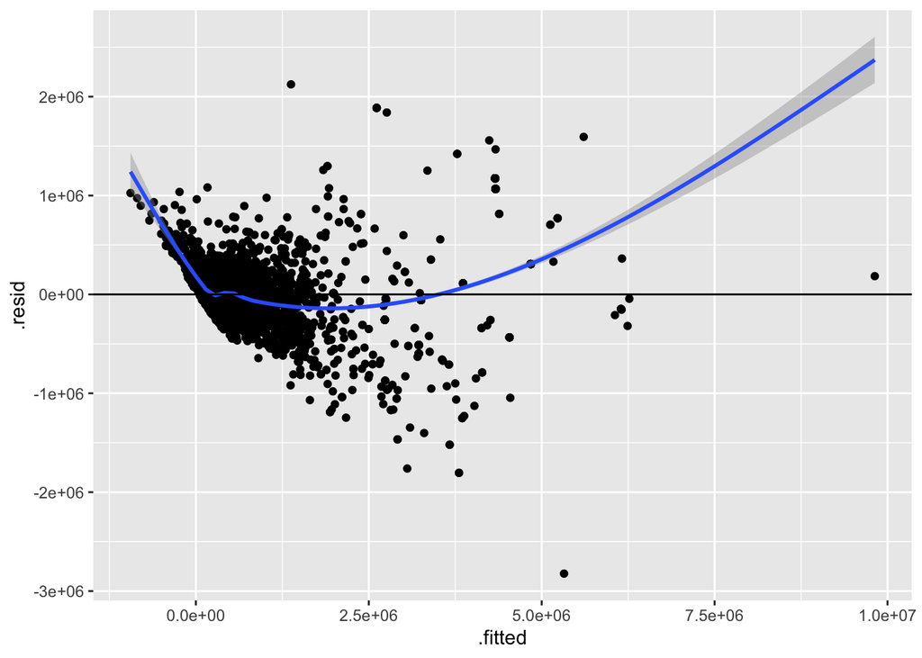

```r
ggplot(reducedint2, aes(x=.fitted, y=.resid)) +
  geom_point() + geom_smooth()+
  geom_hline(yintercept = 0)
```

Box-Cox is used mainly to solve the Nonnormallity and Heteroscedasticity, but it somehow helps to solve the Linearality as well.

```r
library(MASS)
bc=boxcox(reducedint2,lambda=seq(-8,8))
```

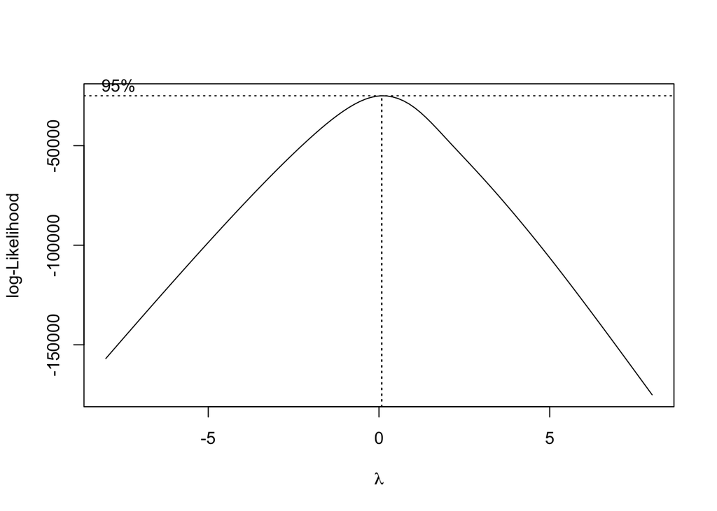

```r
bestlambda=bc$x[which(bc$y==max(bc$y))]
bestlambda
```

```
## [1] 0.08080808
```

```r
bcmodel=lm((((selling_price^0.08080808)-1)/0.08080808) ~ year+km_driven+factor(fuel)+factor(seller_type)+factor(transmission)+factor(owner)+mileage+engine+max_power+seats+torque_rpm + year*km_driven + year*factor(seller_type) + year*factor(transmission) + year*mileage + year*engine + year*max_power + year*torque_rpm + km_driven*factor(seller_type) + km_driven*factor(transmission) + km_driven*max_power + factor(fuel)*factor(transmission) + factor(fuel)*factor(owner) + factor(seller_type)*factor(transmission) + factor(seller_type)*factor(owner) + factor(seller_type)*mileage + factor(seller_type)*engine +factor(seller_type)*max_power + factor(transmission)*factor(owner) + factor(transmission)*mileage + factor(transmission)*engine + factor(transmission)*max_power + factor(transmission)*seats + factor(transmission)*torque_rpm + factor(owner)*mileage + factor(owner)*engine + mileage*engine + mileage*max_power + engine*max_power + engine*torque_rpm + max_power*seats + max_power*torque_rpm, data=car_dataset)
summary(bcmodel)
```

```
##
## Call:
## lm(formula = (((selling_price^0.08080808) - 1)/0.08080808) ~
##     year + km_driven + factor(fuel) + factor(seller_type) + factor(transmission) +
##         factor(owner) + mileage + engine + max_power + seats +
##         torque_rpm + year * km_driven + year * factor(seller_type) +
##         year * factor(transmission) + year * mileage + year *
##         engine + year * max_power + year * torque_rpm + km_driven *
##         factor(seller_type) + km_driven * factor(transmission) +
##         km_driven * max_power + factor(fuel) * factor(transmission) +
##         factor(fuel) * factor(owner) + factor(seller_type) *
##         factor(transmission) + factor(seller_type) * factor(owner) +
##         factor(seller_type) * mileage + factor(seller_type) *
##         engine + factor(seller_type) * max_power + factor(transmission) *
##         factor(owner) + factor(transmission) * mileage + factor(transmission) *
##         engine + factor(transmission) * max_power + factor(transmission) *
##         seats + factor(transmission) * torque_rpm + factor(owner) *
##         mileage + factor(owner) * engine + mileage * engine +
##         mileage * max_power + engine * max_power + engine * torque_rpm +
##         max_power * seats + max_power * torque_rpm, data = car_dataset)
##
## Residuals:
##     Min      1Q  Median      3Q     Max
## -4.1559 -0.4235  0.0429  0.4736  3.9419
##
## Coefficients: (11 not defined because of singularities)
##                                                                         Estimate
## (Intercept)                                                           -2.339e+02
## year                                                                   1.247e-01
## km_driven                                                              8.509e-04
## factor(fuel)Diesel                                                     1.023e+00
## factor(fuel)LPG                                                        3.672e-01
## factor(fuel)Petrol                                                    -5.083e-02
## factor(seller_type)Individual                                          3.861e+01
## factor(seller_type)Trustmark Dealer                                   -3.320e+02
## factor(transmission)Manual                                            -5.458e+01
## factor(owner)Fourth & Above Owner                                      1.023e+00
## factor(owner)Second Owner                                             -1.496e+00
## factor(owner)Test Drive Car                                            2.636e+01
## factor(owner)Third Owner                                              -5.416e-01
```

[output cut: 402 more lines]

```
## factor(owner)Second Owner:engine                                      ***
## factor(owner)Test Drive Car:engine
## factor(owner)Third Owner:engine                                       .
## mileage:engine                                                        ***
## mileage:max_power
## engine:max_power                                                      ***
## engine:torque_rpm                                                     ***
## max_power:seats
## max_power:torque_rpm                                                  ***
## ---
## Signif. codes:  0 '***' 0.001 '**' 0.01 '*' 0.05 '.' 0.1 ' ' 1
##
## Residual standard error: 0.768 on 7782 degrees of freedom
## Multiple R-squared:  0.895,  Adjusted R-squared:  0.894
## F-statistic:   921 on 72 and 7782 DF,  p-value: < 2.2e-16
```

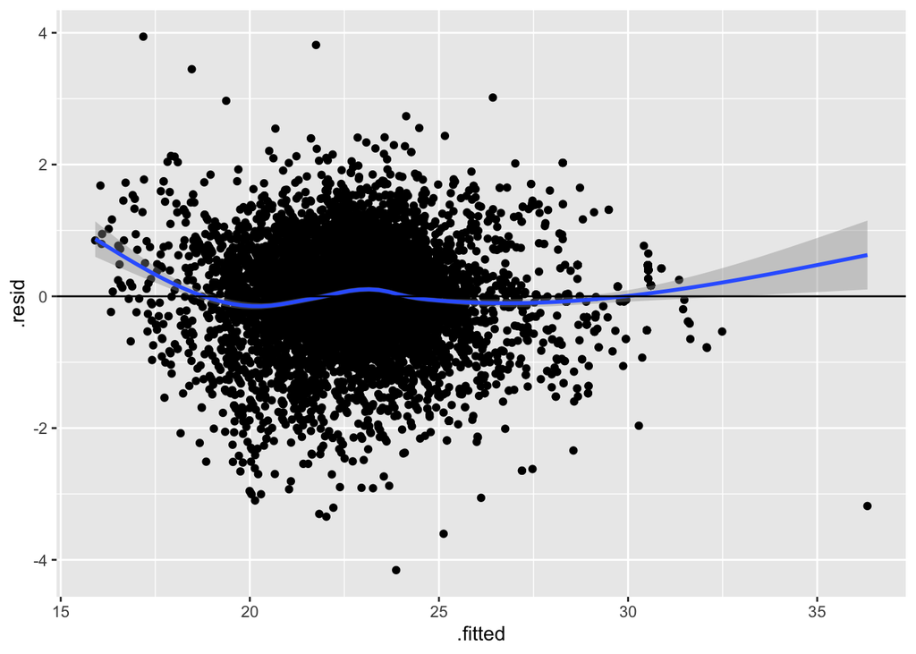

```r
library(ggplot2)
ggplot(bcmodel, aes(x=.fitted, y=.resid)) +
  geom_point() + geom_smooth()+
  geom_hline(yintercept = 0)
```

# Cooks distance for outliers

```r
car_dataset[cooks.distance(reducedint2)>1,]
```

|  | name | year | selling_price | km_driven | fuel | seller_type | transmission | owner | mileage | engine | max_power | torque | seats | torque_nm | torque_rpm |
| --- | --- | --- | --- | --- | --- | --- | --- | --- | --- | --- | --- | --- | --- | --- | --- |
| NA | NA | NA | NA | NA | NA | NA | NA | NA | NA | NA | NA | NA | NA | NA | NA |
| NA.1 | NA | NA | NA | NA | NA | NA | NA | NA | NA | NA | NA | NA | NA | NA | NA |
| NA.2 | NA | NA | NA | NA | NA | NA | NA | NA | NA | NA | NA | NA | NA | NA | NA |

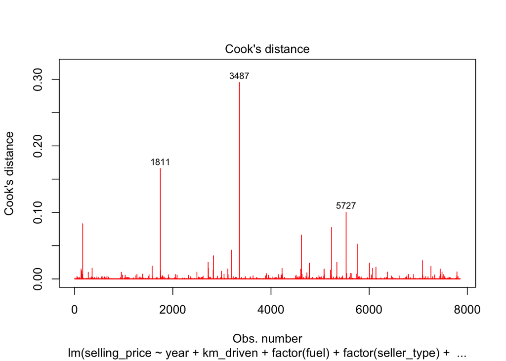

```r
plot(reducedint2,pch=18,col="red",which=c(4))
```

```r
lev=hatvalues(reducedint2)
outlier3p = lev[lev>(3*28/7855)]
#print(outlier3p)
```

```r
library(MASS)
bc=boxcox(reducedint2,lambda=seq(-8,8))
```

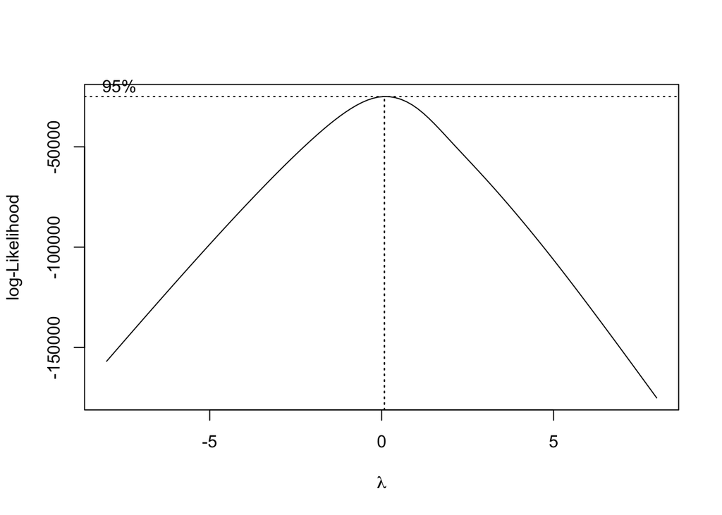

```r
bestlambda=bc$x[which(bc$y==max(bc$y))]
bestlambda
```

```
## [1] 0.08080808
```

```r
bcmodel=lm((((selling_price^0.08080808)-1)/0.08080808) ~ year+km_driven+factor(fuel)+factor(seller_type)+factor(transmission)+factor(owner)+mileage+engine+max_power+seats+torque_rpm + year*km_driven + year*factor(seller_type) + year*factor(transmission) + year*mileage + year*engine + year*max_power + year*torque_rpm + km_driven*factor(seller_type) + km_driven*factor(transmission) + km_driven*max_power + factor(fuel)*factor(transmission) + factor(fuel)*factor(owner) + factor(seller_type)*factor(transmission) + factor(seller_type)*factor(owner) + factor(seller_type)*mileage + factor(seller_type)*engine +factor(seller_type)*max_power + factor(transmission)*factor(owner) + factor(transmission)*mileage + factor(transmission)*engine + factor(transmission)*max_power + factor(transmission)*seats + factor(transmission)*torque_rpm + factor(owner)*mileage + factor(owner)*engine + mileage*engine + mileage*max_power + engine*max_power + engine*torque_rpm + max_power*seats + max_power*torque_rpm, data=car_dataset)
summary(bcmodel)
```

```
##
## Call:
## lm(formula = (((selling_price^0.08080808) - 1)/0.08080808) ~
##     year + km_driven + factor(fuel) + factor(seller_type) + factor(transmission) +
##         factor(owner) + mileage + engine + max_power + seats +
##         torque_rpm + year * km_driven + year * factor(seller_type) +
##         year * factor(transmission) + year * mileage + year *
##         engine + year * max_power + year * torque_rpm + km_driven *
##         factor(seller_type) + km_driven * factor(transmission) +
##         km_driven * max_power + factor(fuel) * factor(transmission) +
##         factor(fuel) * factor(owner) + factor(seller_type) *
##         factor(transmission) + factor(seller_type) * factor(owner) +
##         factor(seller_type) * mileage + factor(seller_type) *
##         engine + factor(seller_type) * max_power + factor(transmission) *
##         factor(owner) + factor(transmission) * mileage + factor(transmission) *
##         engine + factor(transmission) * max_power + factor(transmission) *
##         seats + factor(transmission) * torque_rpm + factor(owner) *
##         mileage + factor(owner) * engine + mileage * engine +
##         mileage * max_power + engine * max_power + engine * torque_rpm +
##         max_power * seats + max_power * torque_rpm, data = car_dataset)
##
## Residuals:
##     Min      1Q  Median      3Q     Max
## -4.1559 -0.4235  0.0429  0.4736  3.9419
##
## Coefficients: (11 not defined because of singularities)
##                                                                         Estimate
## (Intercept)                                                           -2.339e+02
## year                                                                   1.247e-01
## km_driven                                                              8.509e-04
## factor(fuel)Diesel                                                     1.023e+00
## factor(fuel)LPG                                                        3.672e-01
## factor(fuel)Petrol                                                    -5.083e-02
## factor(seller_type)Individual                                          3.861e+01
## factor(seller_type)Trustmark Dealer                                   -3.320e+02
## factor(transmission)Manual                                            -5.458e+01
## factor(owner)Fourth & Above Owner                                      1.023e+00
## factor(owner)Second Owner                                             -1.496e+00
## factor(owner)Test Drive Car                                            2.636e+01
## factor(owner)Third Owner                                              -5.416e-01
```

[output cut: 402 more lines]

```
## factor(owner)Second Owner:engine                                      ***
## factor(owner)Test Drive Car:engine
## factor(owner)Third Owner:engine                                       .
## mileage:engine                                                        ***
## mileage:max_power
## engine:max_power                                                      ***
## engine:torque_rpm                                                     ***
## max_power:seats
## max_power:torque_rpm                                                  ***
## ---
## Signif. codes:  0 '***' 0.001 '**' 0.01 '*' 0.05 '.' 0.1 ' ' 1
##
## Residual standard error: 0.768 on 7782 degrees of freedom
## Multiple R-squared:  0.895,  Adjusted R-squared:  0.894
## F-statistic:   921 on 72 and 7782 DF,  p-value: < 2.2e-16
```

```r
library(lmtest)
bptest(firstordermodel)
```

```
##
##  studentized Breusch-Pagan test
##
## data:  firstordermodel
## BP = 2413.8, df = 17, p-value < 2.2e-16
```

```r
bptest(reducedint2)
```

```
##
##  studentized Breusch-Pagan test
##
## data:  reducedint2
## BP = 3000.7, df = 72, p-value < 2.2e-16
```

```r
bptest(reducedint3)
```

```
##
##  studentized Breusch-Pagan test
##
## data:  reducedint3
## BP = 1040.6, df = 72, p-value < 2.2e-16
```

```r
bptest(bcmodel)
```

```
##
##  studentized Breusch-Pagan test
##
## data:  bcmodel
## BP = 1014.3, df = 72, p-value < 2.2e-16
```

Residual Plot

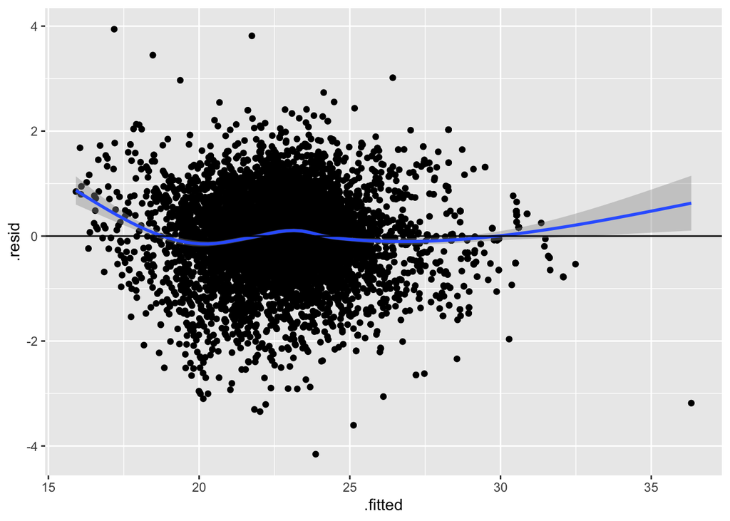

```r
#residual vs fitted data plot for the finalintermodel model
ggplot(bcmodel, aes(x=.fitted, y=.resid)) +
  geom_point() +geom_smooth()+
  geom_hline(yintercept = 0)
```